# GR4058 Week 02

Ben Goodrich

September 12, 2017

# Course Server

To log onto the server for this course,

1. Go to https://ssol.columbia.edu and log in with your UNI and password. Then click on “Academic Profile” and then click on the “Change” menu to select the option to show your personal data. Note what your Person ID (PID) is. If you get confused, watch this https://www.youtube.com/watch?v=mVx_cLDQrzg .
2. Go to http://rstudio.qmss.columbia.edu:8787 and log in using your UNI as the Username and the PID you found in Step 1 as the password.
3. Click on Tools and then Shell … to open a terminal emulator. Enter the command “passwd” (without quotes) to change your password from your PID to a password of your choosing. Do not choose a dumb password.
4. Click Tools and then Global Options … Uncheck the box that says “Restore .RData into workspace at startup” and right below that click on the menu that says Ask next to “Save workspace to .RData on exit” and change Ask to Never. Then click Apply at the bottom and finally OK.

Although you need to have R and RStudio installed on your laptop and may prefer to use R that way, you may use this server for classwork (not for research). You should also do step 4 for any RStudios you may have installed locally on computers.

# Piazza

To log onto Piazza,

1. Go to https://courseworks2.columbia.edu and log in with your UNI and password.
2. Go to the page for GR4058
3. Click on the Piazza link on the left toward the bottom
4. Follow the instructions. Do not choose a dumb password.

If you cannot log on to Canvas, go to https://piazza.com/columbia/fall2017/qmssgr4058_001_2017_3dataminingforsocialscience

A few notes on formatting:

- Italics merely *emphasizes* some point, as in English.
- Boldface **refers** to menu items, tabs, icons, etc. in the RStudio application.
- Highlighted `text` inline pertains to R syntax, and the blue-gray boxes contain entire lines of R code.
- The `##` symbol at the start of a line means that everything that follows on that line is the result the R prints to the screen after evaluating the R code in the blue-gray boxes.

To learn more about the RMarkdown format, which is similar to that of Wikipedia

- Click on **Help** then **Markdown Quick Reference**
- Click on **Help** then **Cheatsheets** then either **R Markdown Cheat Sheet** or **R Markdown Reference Guide** or
- For more details on using R Markdown see http://rmarkdown.rstudio.com

# Why R

Wickham’s other book lists several reasons (not all of which are unique to R)

1. Free, open source, and (mostly) platform independent
2. There are now $11398$ packages for R
3. New algorithims are usually implemented in R first
4. Features that facilitate data analysis with real world data
5. A large community of R users that post on the internet
6. Advanced implementations of tools that help communicate statistical results, such as RMarkdown
7. Funcational programming allows short but clear code
8. Has a great Integrated Development Environment (IDE), namely RStudio
9. Permits metaprogramming on the R language itself, which is powerful (and dangerous)
10. Interfaces with compiled code like C, C++, and Fortran

To get the most out of R, Wickham recommends two meta-techniques

1. Read lots of R code (and start tweaking it)
2. Adopt a scientitic mindset when coding (create reproducible examples, etc.)

There are lots of places on the internet to get help with R, but for the purpose of GR4058, you should only ask questions on our course Piazza page (rather than StackOverflow, etc.)

# RStudio Panels

The RStudio IDE consists of four panels. You can resize them by placing the mouse on the edge of one of the panels and dragging to make it smaller or larger. You could also reconfigure their locations and contents, but here we will assume that the four panels have the stock configuration. Each panel also has rectangles in the top right to make the panel minimized or maximized, which may be used to uncover or cover the panel above or below.

## Console

The bottom-left panel is called the Console and it is where R code is executed. You can type anything at the `>` prompt, press Enter, and see the result. In this subsection, we will also introduce a little bit of the R language. For example, the Console can be used like a calculator, so try some calculation now.

```r
(2 + 3) * 6 / 10 - 1
```

[output not shown]

The `[1]` in the print output indicates that you only asked R to show you one thing. R can be used to make several calculations in one step, but we will get to that later. You want to get in the habit of thinking through what each subexpression evaluates to. For example, $2 + 3$ evaluates to $5$, $5\times\frac{6}{10}$ evaluates to $3$, and $3 - 1 = 2$. Going through this process every time will make it easier to understand more complicated expressions.

Of course, R is not merely a desk calculator and has essentially every mathematical function you have ever heard of, many that you have never heard of, and the ability for users to write their own functions. Most of the built-in functions are fairly self-explanatory. You have the basic four arithmetic operators, plus `^` for exponentiation and two others:

```
## + - * ^ %% %/% /
```

The two non-obvious ones — `%%` and `%/%` — are the modulus and integer division operators, which you might know from long division in elementary school but are not used much. For example, seven divided by two is three with a remainder of one or, in decimal notation, $3.5$:

```r
7 %/% 2
```

```
## [1] 3
```

```r
7 %% 2
```

```
## [1] 1
```

```r
7 / 2
```

```
## [1] 3.5
```

The `*` operator is for scalar multiplication. For vector or matrix multiplication, use the `%*%` operator, which is explained in more detail later in the semester. Next you have various comparison operators:

```
## == > < != <= >=
```

Note that in R, like many other computer languages, the “double equals” sign is used to test whether the two sides are equal to each other. As we will learn, the “single equals” sign is used for an entirely different purpose. The `!=` operator asks if the two sides are not equal to each other (and if so returns `TRUE`). For example,

```r
( (2 + 3) * 6 / 10 - 1 ) == 2
```

```
## [1] TRUE
```

```r
( 9 %/% 3 ) > 2
```

```
## [1] TRUE
```

```r
( 7 %% 2 ) < 1
```

```
## [1] FALSE
```

```r
( 7 / 2 ) != 3
```

```
## [1] TRUE
```

```r
( 7 / 2 ) <= 3
```

```
## [1] FALSE
```

```r
( 7 / 2 ) >= 3
```

```
## [1] TRUE
```

Finally, the `!` operator indicates logical negation, so

```r
!TRUE
```

```
## [1] FALSE
```

```r
!FALSE
```

```
## [1] TRUE
```

The two logical operators

```
## & |
```

can be translated as “AND” and “OR” respectively. The former returns `TRUE` if and only if both the left and the right sides evaluate to `TRUE` and the latter returns `TRUE` if either the left and the right side evaluates to `TRUE`. Thus, based on the above

```r
(( (2 + 3) * 6 / 10 - 1 ) == 2) & (( 9 %/% 3 ) > 2)
```

```
## [1] TRUE
```

```r
(( 7 %% 2 ) < 1) & (( 7 / 2 ) != 3)
```

```
## [1] FALSE
```

```r
(( 7 / 2 ) <= 3) | (( 7 / 2 ) >= 3)
```

```
## [1] TRUE
```

There is a convention in R (and many other programming languages) that for the purpose of “arithmetic” operations, `TRUE` is mapped to $1$ and `FALSE` is mapped to $0$, so

```r
TRUE + TRUE
```

```
## [1] 2
```

```r
TRUE^3
```

```
## [1] 1
```

```r
TRUE - FALSE
```

```
## [1] 1
```

```r
(( 7 / 2 ) <= 3) * (( 7 / 2 ) >= 3)
```

```
## [1] 0
```

R also has many functions. A function “call” consists of four parts

1. The name of the function
2. An opening (round) parenthesis, `(`
3. The arguments to the function, separated by commas (this is the only situation where commas are used)
   - Arguments can be specified by position (which is what we will do in this  
     subsection)
   - Arguments can be specified by name and an equals sign, `=`, which is more explicit.
4. A closing (round) parenthesis, `)`

The `all()` and `any()` functions are generalizations of `&` and `|` in that they respectively return `TRUE` if all the logical expressions in a set are `TRUE` or return `TRUE` if any of the logical expressions in a set are `TRUE`.

```r
all( ((2 + 3) * 6 / 10 - 1) == 2, (9 %/% 3) > 2, (7 / 2) <= 3 )
```

```
## [1] FALSE
```

```r
any( (9 %/% 3) > 2, (7 / 2) <= 3, TRUE < FALSE )
```

```
## [1] TRUE
```

There are also various mathematical functions

```
## abs acos acosh all any asin asinh atan atanh ceiling cos cosh cospi cummax cummin cumprod cumsum digamma exp expm1 floor gamma lgamma log log10 log1p log2 max min prod range round sign signif sin sinh sinpi sqrt sum tan tanh tanpi trigamma trunc
```

We do not use trigonometry in G4058, but the trig functions are available in R if you ever need them (but remember that they assume radians rather than degrees). We only use the “natural” logarithm function `log()`, so you won’t need to use the base-10 or base-2 logarithms. The functions prefixed by `cum()` are useful for finding the cumulative `max()`, `min()`, `prod()`uct, and `sum()`mation of a set of numbers. Some illustrations

```r
max(sqrt(abs(-4)), exp(log(1)))
```

```
## [1] 2
```

```r
sum(1,2,3,4)
```

```
## [1] 10
```

```r
prod(FALSE,1,2,3,4)
```

```
## [1] 0
```

We will learn more about calling R functions later

You can go back to previous commands using the up arrow key and then possibly change it before pressing Enter. Also, the Home and End keys are good for jumping to the beginning or end of a line (the same can be accomplished with Command / Ctrl+left and Command / Ctrl+right, depending on whether you are using a Mac). You can also type the first three letters of some R function and then pause or press the Tab key to see possible completions that start with those letters. Try typing the token “dat” in the Console and then pause to see the completions.

Finally, if you type a line of R syntax that is incomplete, the R prompt in the Console will change from `>` to `+`. This is not an “addition” sign but a suggestion that R needs more input.

You could complete the line of R syntax by typing some number and pressing Enter. However, often incomplete lines are a sign that you have mismatched parentheses, or quotation marks, or have made some other mistake. If so, you can press the Esc key, and the Console prompt will revert back to `>` so that you can start again.

## Editor

At this point, you have typed a lot of code into the Console and are probably wondering if there is a more permanent way to work with R. The top-left panel is intended for editing R code (inclusive of writing it from scratch) and has a convenient mechanism for piping it to the R Console below. You should type directly into the Console panel only when you are doing something experimental or otherwise will not need the R syntax again in the future. For example, calls to the `help()` and `args()` functions should go directly into the Console and not into the Editor panel script. But everything that can be done in the Console panel can (and often should) be done in the Editor panel.

Increase the size of the Editor panel to something reasonable and type some R expression as if you were writing in the R Console. Now leave the cursor on that line of R code and click the **Run** icon in the upper-right of the Editor panel. You should see the Console panel expand and whatever line you typed in the Editor panel has been piped to and evaluated in the Console panel.

It is even more convenient to use a keyboard shortcut to pipe lines of R code from the Editor panel to the Console panel. On Macs, this keyboard shortcut is executed by holding down the Command key and pressing Enter. On non-Macs, this keyboard shortcut is executed by holding down the Ctrl key and pressing Enter. There are *many* other keyboard shortcuts of various degrees of usefulness that can be found by clicking **Tools** on the RStudio menu at the top and then **Keyboard Shortcuts Help** from the submenu.

R code written in the Editor panel can be saved for later use. To do so, either click the disk icon, click on the **File** menu and then **Save**, or use the keyboard shortcut Command/Ctrl+S depending on whether you are using a Mac. Doing so will open up a conventional dialog that will allow you to choose what directory to save this file as and what name to give it. By convention, R syntax files are given a .R extension, so you might save this file as MyFirstRFile.R.

At this point, we have typed many of the same expressions several times in order to illustrate R syntax. However, the general rule is never to type the same thing twice. Instead, it is better to preserve the result of an R expression in R’s memory using the “assignment” operator. Many computer languages use the “single equals” sign as their assignment operator, which is technically legal in R but is generally discouraged and considered wrong in W4912. R relies on an atypical assignment operator `<-`, which is composed of a less-than sign and a minus sign without any space between them. The assignment operator is used to bind the result of an R expression to a symbol that can subsequently be referred to rather than repeating that R expression.

The assignment operator is used to bind the result of an R expression to a symbol that can subsequently be referred to rather than repeating that R expression. For example,

```r
x <- 5
```

At this point, we can refer to the symbol `x` and the result will be as if we referred to the number $5$.

```r
2 * x
```

```
## [1] 10
```

Here are the rules for assigning to symbols

- The symbol name must consist of letters, numbers, underscores, and periods. In particular, it cannot contain spaces. R is case-sensitive.
- The symbol name cannot start with a number but may contain numbers anywhere else.
- You will still see people use periods in symbol names as a substitute for a space (such as `my.data`), but this is because the underscore was only made legal in $2004$. It is preferable to use the underscore (such as `my_data`) because the period is also used for something else entirely.
- In general, symbol names should be short and reference what is bound to them. Thus, things like `x` should only be used when something arbitrary is bound to it, whereas `age` would be a good symbol for the age(s) of someone and would be a misleading symbol if it were bound to anything else.

Another important aspect of editing R code is to include good code comments. The `#` character is not a hashtag but rather indicates that everything that follows on that line will not be evaluated by R. Thus, you are free to write an explanation as to *why* the code is written that way. Note that comments generally should not be used to indicate *what* the code does; if what the code does is not evident to someone who knows the R syntax, then the code is not written clearly enough in terms of having appropriate symbol names, adequate line breaks, etc. For example,

```r
x <- 9  # assigns 9 to x
sqrt(x) # takes the square root of x
```

```
## [1] 3
```

these code comments add nothing that was not already apparent from the syntax itself. It is preferable to use code comments to explain *why* you are doing something, such as

```r
y <- x * 0.621371 # convert from kilometers to miles
```

But it is better still to let the code do the talking and reserve code comments for when you have to explain something non-trivial. Thus, no comment is really needed if you can use symbol names appropriately

```r
length_in_miles <- length_in_km * 0.621371
```

An R expression can span more than one line, although it is not needed in this case

```r
x <- 2 + # this R expression is incomplete until completed on the next line
  3
x
```

```
## [1] 5
```

The **Source** icon can be used to pipe an entire file to the R Console, and thus is basically equivalent to selecting all the lines and **Run** ning them. However, using **Source** is somewhat better for this purpose for a few reasons

- It catches syntax errors more closely to where the problem occurs and tells you the corresponding line number (although the actual problem may be one line up).
- It silently evaluates each R expression, which can be useful to avoid clutter if you are doing something that your reader does not need to know the details of.
- It forces you to verify that your code is complete and self-contained rather than implicitly relying on some objects that you created by typing directly in the R Console and forgot about.

Basically, whenever you “finish” writing a file of R syntax, save your changes to the disk, restart the R session by clicking on the **Session** menu followed by the **Restart R** submenu, and finally then click on the **Source** icon to execute your entire file. If there are any error messages, then you are not actually “finished”. Fix them and go through the process again.

You can have multiple files open simultaneously. These are represented by tabs in the Editor pane, just like in a web browser.

## Accounting

The top-right panel in RStudio is not essential but is somewhat useful. Nor does it seem to have a well-established name, so we will call it the Accounting panel. It generally has four tabs: Environment, History, Presentation, and Viewer.

### Environment

This is useful for remembering what objects are assigned and what they are bound to (although no substitute for using symbol names that are more informative than `x`). If the object is larger than a single number, the Environment tab will display some abbreviated information about it. For example, if we execute

```r
data("USJudgeRatings")
dim(USJudgeRatings)
```

```
## [1] 43 12
```

then a dataset of ratings that lawyers give to US judges is pulled into the R Console (and bound to the symbol `USJudgeRatings`). The `dim` function returns its dimensions, which are $43$ rows and $12$ columns, which is also given in the Environment tab.

You can click on the spreadsheet-like icon to the right of USJudgeRatings in the environment tab to open a spreadsheet-like representation of the dataset (although it cannot be edited directly). You can click on the arrow to the left of USJudgeRatings in the Environment tab to get more information on its structure.

The **Clear** icon at the top of the Environment tab can be clicked to remove all objects, which can also be accomplished programatically by executing

```r
rm(list = ls())
```

### History

The History tab keeps a record of what commands have been executed, either by typing directly in the Console panel or by piping from the Editor panel. You can double-click to resend that command to the Console (although you have to then press Enter to execute it). Or you can click the **To Source** icon to paste it into your active file in the Editor panel. There are some other icons in the History tab, but they are not too useful.

### Presentation

The Presentation tab is basically a web browser that is used to show HTML presentations that are made in RStudio. This mechanism is a nice way to make simple presentations that utilize R code and R output. Students in W4912 will not be required to make any such presentations, but the TAs may sometimes make them for the review lab sessions.

### Viewer

The Viewer tab is also basically a web browser but shows different stuff than the Presentation tab and is essentially irrelevant to W4912. It is possible to make Shiny apps appear in the Viewer tab, which we might do at some point.

## Miscellaneous

The bottom-right panel contains a grab-bag of stuff, separated into tabs.

### Files

The **Files** tab typically shows the contents of the “working directory”. The idea of a working directory may be unfamiliar to many of you, although Stata also has this idea. The working directory is a folder on your hard drive where R(Studio) will both look for files and save files, images, etc. Basically, everything you need for a project should be included in the working directory or in a folder below the working directory. For example, my working directory for writing this guide is called /opt/Classes/DataMining/Fall2017/Week02.

What if you need to tell R(Studio) to use a different working directory? You can change it with a mouse by clicking on the **Session** menu, then the **Set Working Directory** submenu, and finally **Choose Directory**. Once you complete that, you will see a line like

```
setwd("/opt/Classes/DataMining/Fall2017/Week02")
```

that has been piped into the Console panel.

### Plots

The plots tab shows plots that are generated by R code. We will make tons of plots in G4058. For now, in the Console panel simply execute

```
##
## plot> require(stats) # for lowess, rpois, rnorm
##
## plot> plot(cars)
```

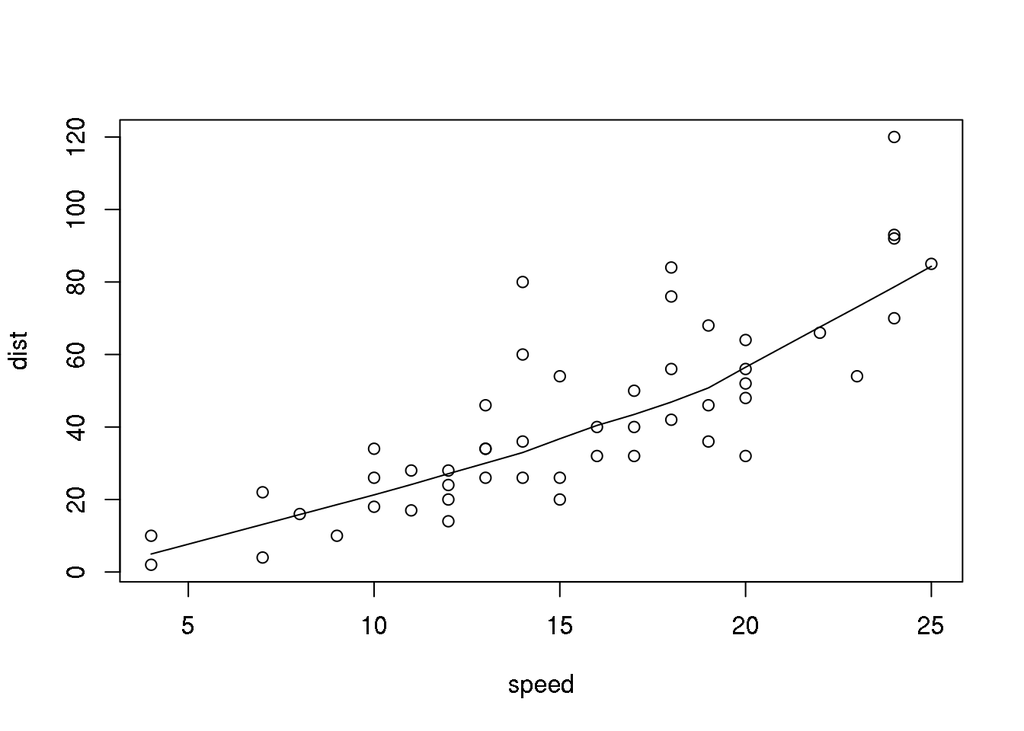

```
##
## plot> lines(lowess(cars))
##
## plot> plot(sin, -pi, 2*pi) # see ?plot.function
```

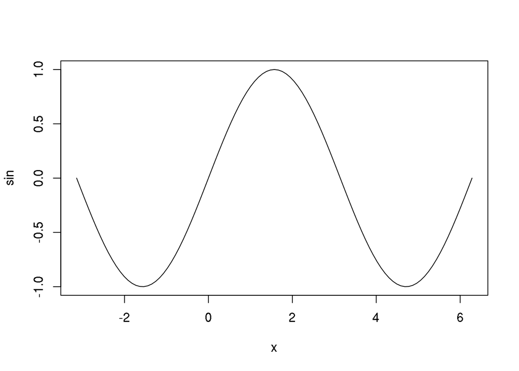

```
##
## plot> ## Discrete Distribution Plot:
## plot> plot(table(rpois(100, 5)), type = "h", col = "red", lwd = 10,
## plot+      main = "rpois(100, lambda = 5)")
```

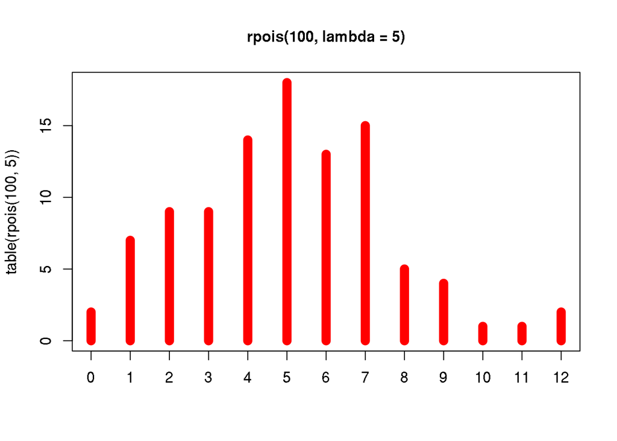

```
##
## plot> ## Simple quantiles/ECDF, see ecdf() {library(stats)} for a better one:
## plot> plot(x <- sort(rnorm(47)), type = "s", main = "plot(x, type = \"s\")")
```

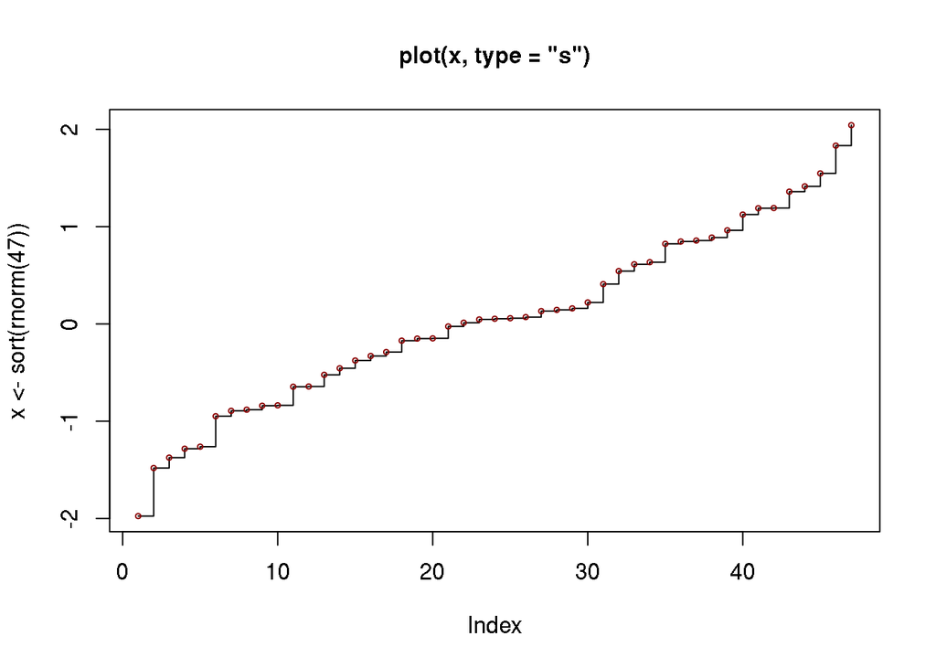

```
##
## plot> points(x, cex = .5, col = "dark red")
```

```r
example(plot) # You have to hit Enter to see the subsequent plots
```

and four plots will appear in the **Plots** tab. You can click on the arrow icons at the top of the **Plots** tab to rewind for fast-forward through your accumulated plots. The **Zoom** icon will open a larger window of your plot. The **Export** icon can be used to save the plot to your hard disk, although it is better to save the plot programmatically by executing R syntax. We will review how to do so in G4058, but briefly the most relevant functions are `savePlot()` to save an existing plot exactly as is, `png()` to open a Portable Network Graphics (PNG) device to write a plot to, and `pdf()` to open a Portable Document Format (PDF) device to write a plot to.

### Packages

The **Packages** tab shows what R packages have been installed to your hard drive. As was mentioned earlier, R packages contain additional functionality that extends the capability of the somewhat minimal version of R that you first downloaded, the same way extensions enhance the functionality of the Firefox web browser. However, once you have installed a package to your hard drive, you have to load it into your R session in order to expose and then use that functionality. This can be done in the **Packages** tab by checking the box to the left of the package name, although it is much better to do so programatically by writing something like

```r
stopifnot(require(ISLR))
```

### Help

The **Help** tab displays the documentation for an R function. The paradoxical thing about R is that in order to get help with some R function, you need to know the name of the R function, when often the basic problem is that you do not know or remember the name of the function you are looking for. In GR4058, the homework assignments will tell you what functions you need to use, although you may need to read their corresponding help pages. There is a search box in the upper-right corner of the **Help** tab where you can type the name of the function and RStudio will assist you by trying to guess what you are looking for. For example, type the word “pdf” (without quotes) into the search box and press Enter. The help page for the `pdf()` function should come up, although it may be more convenient to then click the icon to the right of the printer in the **Help** tab in order to open the help page in a full-sized web browser.

You should use the `help()` functionality to lookup any of the functions that you are not already familiar with.

All help pages for R functions follow the same basic format.

1. Description: This is a brief paragraph or two explaining what the purpose of the function is, in this case it says “`pdf` starts the graphics device driver for producing PDF graphics”
2. Useage: This shows the R syntax for how the function could be called and emphasizes the default values for various arguments to the function
3. Arguments: This is a list of the function’s arguments with some additional explanation as to what each argument entails, whether it is required, and if not what its default value is
4. Details: This explains in a more conversational tone how to use the function and expands upon any topics that would not easily fit into the Arguments section.
5. Value: What is returned by the function. In this case, the `pdf` function does not return any output to the R Console but only creates a PDF file on your hard disk. Thus, the Value section is omitted in this case.
6. See Also: Other functions that provide similar functionality that you may be interested in using
7. Exampes: This is often the most useful section and gives a somewhat minimal example of how to use the function. Or you can use the `example()` function to just run the example code without reading the entire help page like we did above.

To make a long story short in the case of `pdf`, you could do something like

```r
dev.off() # to close whatever plotting device might already be open
pdf(file = "plot_example.pdf", width = 6, height = 9, fonts = "Times")
example(plot) # or some other plot you want to save
dev.off()
```

and R will make a PDF called plot_example.pdf in the current working directory of the four plots you made in the Plots subsection. However, you will not see these plots under the **Plots** tab. In real projects, this programmatic approach to saving plots is preferable to clicking the **Export** button under the **Plots** tab because it automatically saves the new plot whenever you change the R code that generates it.

The help search box is case-sensitive. Thus, if you searched for “PDF”, no hits would be returned. The `apropos` function is somewhat useful if you kind of know what you are looking for but do not know exactly how it is spelled. For example, you could execute in the Console panel

```r
apropos("PDF", mode = "function")
```

```
## [1] "cairo_pdf"    "dev.copy2pdf" "pdf"          "pdf.options"
## [5] "pdfFonts"
```

and you will see all functions that have the three letters “PDF” in them, regardless of case.

Finally, R packages often have vignettes that demonstrate basic useage of an R package in a less-structured (and often more useful) format than the help pages. You can download the vignettes from the package’s webpage on CRAN or access them from inside RStudio with

```r
browseVignettes(package = "AER") # or another R package
```

# Data Structures in R

Data in R can take a variety of forms, Wickham’s other book includes the following table

| Dimensions | Homogenous | Heterogeneous |
| --- | --- | --- |
| 1d | atomic `vector` | `list` |
| 2d | `matrix` | `data.frame` |
| nd | `array` |  |

There are no “scalars” in R but you can have a `vector` of length one, which may or may not be numeric.

The `str` function is useful for understanding the structure of an object

```r
data("USJudgeRatings")
str(USJudgeRatings)
```

```
## 'data.frame':    43 obs. of  12 variables:
##  $ CONT: num  5.7 6.8 7.2 6.8 7.3 6.2 10.6 7 7.3 8.2 ...
##  $ INTG: num  7.9 8.9 8.1 8.8 6.4 8.8 9 5.9 8.9 7.9 ...
##  $ DMNR: num  7.7 8.8 7.8 8.5 4.3 8.7 8.9 4.9 8.9 6.7 ...
##  $ DILG: num  7.3 8.5 7.8 8.8 6.5 8.5 8.7 5.1 8.7 8.1 ...
##  $ CFMG: num  7.1 7.8 7.5 8.3 6 7.9 8.5 5.4 8.6 7.9 ...
##  $ DECI: num  7.4 8.1 7.6 8.5 6.2 8 8.5 5.9 8.5 8 ...
##  $ PREP: num  7.1 8 7.5 8.7 5.7 8.1 8.5 4.8 8.4 7.9 ...
##  $ FAMI: num  7.1 8 7.5 8.7 5.7 8 8.5 5.1 8.4 8.1 ...
##  $ ORAL: num  7.1 7.8 7.3 8.4 5.1 8 8.6 4.7 8.4 7.7 ...
##  $ WRIT: num  7 7.9 7.4 8.5 5.3 8 8.4 4.9 8.5 7.8 ...
##  $ PHYS: num  8.3 8.5 7.9 8.8 5.5 8.6 9.1 6.8 8.8 8.5 ...
##  $ RTEN: num  7.8 8.7 7.8 8.7 4.8 8.6 9 5 8.8 7.9 ...
```

and the same information is available by clicking on the arrow icon to the left of the object in the Environment tab in the top right.

## The `vector`

A `vector` in R has three important components

1. Its type, which is given by the `typeof` function
2. Its length, which is given by the `length` function
3. Its attributes, which are metadata given by the `attributes` function

A vector is usually one of four types

1. numeric, which is to say double-precision real
2. integer, which is a signed integer
3. character, which is anything in quotation marks
4. logical, which is `TRUE` or `FALSE`

We can use the `c()` function to create a `vector`

```r
num <- c(3.5, 10)           # intermediate flexibility
int <- c(-2L, 4L)           # intermediate flexibility
char <- c("hello", "world") # most flexible
logic <- c(TRUE, FALSE)     # least flexible
```

But any vector can also have `NA` to indicate a missing value. Each of the four main types of vectors can be tested with the corresponding `is.*` function

```r
is.numeric(num)
```

```
## [1] TRUE
```

```r
is.integer(int)
```

```
## [1] TRUE
```

```r
is.character(char)
```

```
## [1] TRUE
```

```r
is.logical(logic)
```

```
## [1] TRUE
```

```r
is.character(logic)
```

```
## [1] FALSE
```

There are also `as.*` functions that can be used to coerce a vector to another type of vector

```r
as.numeric(int)
```

```
## [1] -2  4
```

```r
as.integer(num)
```

```
## [1]  3 10
```

```r
as.character(num)
```

```
## [1] "3.5" "10"
```

```r
as.logical(char)
```

```
## [1] NA NA
```

### The `factor`

A `factor` is essentially a special kind of vector that is used to represent categorical data. R is much stricter about categorical data than most other statistical programs, which many people find pedantic but only because they have not thought about such things carefully. A factor defines a correspondence between integer codes and their descriptive labels and is usually created by the `factor` function, such as

```r
religion <- factor(c(1,1,2,1,3,1,1,1,4), levels = 1:4,
                  labels = c("Christian", "Jewish", "Muslim", "Other"))
levels(religion)
```

```
## [1] "Christian" "Jewish"    "Muslim"    "Other"
```

This can be used if you have data on individuals’ religions where there are four possible values. We tend to think of religions as being unordered, but some factors have an unambiguous order such as

```r
approval <- factor(c(1,3,2,2,3,1), levels = 1:3,
                   labels = c("Disapprove", "Neutral", "Approve"), ordered = TRUE)
nlevels(approval)
```

```
## [1] 3
```

Be aware that if you do not specify the `levels` and `labels` arguments, R will use alpha-numerical ordering of the categories, regardless of whether `ordered = TRUE` and alpha-numerical categories are often arbitrary.

## The `matrix` and the `array`

A `matrix` is a collection of vectors that have the same length. Again, you can have a matrix whose elements are characters, in which case linear algebra operations will not work. The usual way to create a matrix is with the `matrix()` function, such as

```r
mat <- matrix(1:6, nrow = 3, ncol = 2)
mat
```

```
##      [,1] [,2]
## [1,]    1    4
## [2,]    2    5
## [3,]    3    6
```

There are three important functions for checking the dimensionality of a `matrix`

```r
dim(mat)
```

```
## [1] 3 2
```

```r
nrow(mat)
```

```
## [1] 3
```

```r
ncol(mat)
```

```
## [1] 2
```

```r
is.matrix(mat)
```

```
## [1] TRUE
```

You can also create a matrix by binding vectors, either column-wise or row-wise using the `cbind()` and `rbind()` functions respectively, as in

```r
mat <- cbind(6:4, 3:1)
mat
```

```
##      [,1] [,2]
## [1,]    6    3
## [2,]    5    2
## [3,]    4    1
```

```r
mat <- rbind(1:2, 3:4, 5:6)
mat
```

```
##      [,1] [,2]
## [1,]    1    2
## [2,]    3    4
## [3,]    5    6
```

This last matrix could also be created simply by specifying `byrow = TRUE` in the call to the `matrix()` function:

```r
mat <- matrix(1:6, nrow = 3, ncol = 2, byrow = TRUE)
mat
```

```
##      [,1] [,2]
## [1,]    1    2
## [2,]    3    4
## [3,]    5    6
```

An `array` is essentially a multidimensional generalization of vectors and matrices (but without linear algebra operations). Conversely, a vector is a one-dimensional array and a matrix is a two-dimensional array. Arrays are typically created with the `array()` function, as in

```r
arr <- array(1:24, dim = c(4, 2, 3)) # 4 rows, 2 columns, 3 shelves
arr
```

```
## , , 1
##
##      [,1] [,2]
## [1,]    1    5
## [2,]    2    6
## [3,]    3    7
## [4,]    4    8
##
## , , 2
##
##      [,1] [,2]
## [1,]    9   13
## [2,]   10   14
## [3,]   11   15
## [4,]   12   16
##
## , , 3
##
##      [,1] [,2]
## [1,]   17   21
## [2,]   18   22
## [3,]   19   23
## [4,]   20   24
```

```r
dim(arr)
```

```
## [1] 4 2 3
```

```r
nrow(arr)
```

```
## [1] 4
```

```r
ncol(arr)
```

```
## [1] 2
```

```r
is.matrix(arr)
```

```
## [1] FALSE
```

```r
is.array(arr)
```

```
## [1] TRUE
```

## The `list`

A `list` is a container of containers and its elements need not be of the same type. Thus, this is a list containing a vector, a factor, a matrix, and an array that we created above

```r
lst <- list(logic, approval, mat, arr)
is.list(lst)
```

```
## [1] TRUE
```

```r
length(lst)
```

```
## [1] 4
```

A `list` can contain another `list` as one of its elements. A `list` can have named elements, although this one currently does not

```r
names(lst)
```

[output not shown]

So, we can assign the names as follows

```r
names(lst) <- c("first", "second", "third", "fourth")
```

but we could use any character vector of length $4$ for the names. Many R functions return a `list` in order to hold heterogenous information.

## The `data.frame`

A `data.frame` is a special case of a `list` where every list element has the same length. Thus, a `data.frame` resembles a matrix conceptually but unlike a `matrix` in R, the “columns” of a `data.frame` need not be the same type. Here is a `data.frame` of heterogenous vectors

```r
df <- data.frame(num, char, logic)
is.data.frame(df)
```

```
## [1] TRUE
```

```r
dim(df) # 2 rows, 3 columns
```

```
## [1] 2 3
```

```r
df
```

```
##    num  char logic
## 1  3.5 hello  TRUE
## 2 10.0 world FALSE
```

Thus, a `data.frame` can also accomodate a mix of factors and numeric data, which is customary for datasets in the social sciences. When you read data into R, the output of the function will usually be a `data.frame`.

You can inspect the column (or row names) of a `data.frame` with

```r
colnames(df)
```

```
## [1] "num"   "char"  "logic"
```

```r
rownames(df)
```

```
## [1] "1" "2"
```

and these can have a character vector assigned to them, such as

```r
rownames(df) <- c("one", "two")
rownames(df)
```

```
## [1] "one" "two"
```

You can coerce a `matrix` into a `data.frame` (and vice versa)

```r
df <- as.data.frame(mat)
```

Like a `matrix`, it is possible to use the `cbind` or `rbind` function to bind two `data.frame`s together by column or by row respectively.

## `tibble`s

Wickham has a new R package called **tibble** that introduces a new type of object, also called a `tibble` that behaves pretty much like a `data.frame` but avoids some of the ideosyncracies of `data.frame`s. We will talk more about `tibble`s next week.

# Subsetting R Objects

If you have one of the containers discussed earlier, then you can subset them using expressions within brackets.

- By position, with an integer (vector)

  ```r
  letters[4]
  ```

  ```
  ## [1] "d"
  ```

  ```r
  letters[c(1,5,9,15,21)]
  ```

  ```
  ## [1] "a" "e" "i" "o" "u"
  ```

- Conversely, you can obtain all elements except those specified with a negative integer (vector)

  ```r
  letters[-4]
  ```

  ```
  ##  [1] "a" "b" "c" "e" "f" "g" "h" "i" "j" "k" "l" "m" "n" "o" "p" "q" "r"
  ## [18] "s" "t" "u" "v" "w" "x" "y" "z"
  ```

  ```r
  letters[c(-2,-5)]
  ```

  ```
  ##  [1] "a" "c" "d" "f" "g" "h" "i" "j" "k" "l" "m" "n" "o" "p" "q" "r" "s"
  ## [18] "t" "u" "v" "w" "x" "y" "z"
  ```

- With a logical vector of the same length as the object being subsetted

  ```r
  char[logic]
  ```

  ```
  ## [1] "hello"
  ```

  ```r
  char[!logic]
  ```

  ```
  ## [1] "world"
  ```

- By name, with a character (vector). In the case of a matrix(-like) object, you can subset on either the rownames, the columnnames, or both, as in:

  ```r
  state.x77["New York", ]
  ```

  ```
  ## Population     Income Illiteracy   Life Exp     Murder    HS Grad
  ##   18076.00    4903.00       1.40      70.55      10.90      52.70
  ##      Frost       Area
  ##      82.00   47831.00
  ```

  ```r
  state.x77[ , c("Population", "Murder")]
  ```

  ```
  ##                Population Murder
  ## Alabama              3615   15.1
  ## Alaska                365   11.3
  ## Arizona              2212    7.8
  ## Arkansas             2110   10.1
  ## California          21198   10.3
  ## Colorado             2541    6.8
  ## Connecticut          3100    3.1
  ## Delaware              579    6.2
  ## Florida              8277   10.7
  ## Georgia              4931   13.9
  ## Hawaii                868    6.2
  ## Idaho                 813    5.3
  ## Illinois            11197   10.3
  ## Indiana              5313    7.1
  ## Iowa                 2861    2.3
  ## Kansas               2280    4.5
  ## Kentucky             3387   10.6
  ## Louisiana            3806   13.2
  ## Maine                1058    2.7
  ## Maryland             4122    8.5
  ## Massachusetts        5814    3.3
  ## Michigan             9111   11.1
  ## Minnesota            3921    2.3
  ## Mississippi          2341   12.5
  ## Missouri             4767    9.3
  ## Montana               746    5.0
  ## Nebraska             1544    2.9
  ## Nevada                590   11.5
  ## New Hampshire         812    3.3
  ## New Jersey           7333    5.2
  ## New Mexico           1144    9.7
  ## New York            18076   10.9
  ## North Carolina       5441   11.1
  ## North Dakota          637    1.4
  ## Ohio                10735    7.4
  ## Oklahoma             2715    6.4
  ## Oregon               2284    4.2
  ## Pennsylvania        11860    6.1
  ## Rhode Island          931    2.4
  ## South Carolina       2816   11.6
  ## South Dakota          681    1.7
  ## Tennessee            4173   11.0
  ## Texas               12237   12.2
  ## Utah                 1203    4.5
  ## Vermont               472    5.5
  ## Virginia             4981    9.5
  ## Washington           3559    4.3
  ## West Virginia        1799    6.7
  ## Wisconsin            4589    3.0
  ## Wyoming               376    6.9
  ```

  ```r
  state.x77["New York", c("Population", "Murder")]
  ```

  ```
  ## Population     Murder
  ##    18076.0       10.9
  ```

- For a `data.frame`, there are other ways to select rows or columns that will be discussed in the following weeks.

In the case of a list(-like) object, there are three ways to subset

1. With “single brackets”, the result is a shorter list

   ```r
   lst[2:3]
   ```

   ```
   ## $second
   ## [1] Disapprove Approve    Neutral    Neutral    Approve    Disapprove
   ## Levels: Disapprove < Neutral < Approve
   ##
   ## $third
   ##      [,1] [,2]
   ## [1,]    1    2
   ## [2,]    3    4
   ## [3,]    5    6
   ```

2. With “double brackets”, the result is the corresponding list element

   ```r
   lst[[1]]
   ```

   ```
   ## [1]  TRUE FALSE
   ```

3. With the dollar sign, the result is the list element with that name

   ```r
   USJudgeRatings$PHYS
   ```

   ```
   ##  [1] 8.3 8.5 7.9 8.8 5.5 8.6 9.1 6.8 8.8 8.5 8.4 6.9 8.1 6.2 8.4 8.0 6.9
   ## [18] 8.1 8.0 7.2 7.5 7.4 4.7 7.8 8.7 9.0 8.3 8.8 8.4 8.9 8.4 8.1 8.7 8.8
   ## [35] 6.3 8.0 8.1 8.5 8.0 8.1 7.6 8.3 7.8
   ```

   The dollar sign notation is particularly useful in the R Console because you can type the first few letters of the element name and then press the Tab key to show the possible completions if you do not remember how to spell the element name exactly.

In all of these cases, it is also possible to assign to a subset of a container. For example,

```r
char[2] <- "Newman"
df$char <- char
df[ ,"char"]
```

[output not shown]

To review,

  ```r
  (2 + 3) * 4
  ```

  ```
  ## [1] 20
  ```

  ```r
  log(10)
  ```

  ```
  ## [1] 2.302585
  ```

  ```r
  sinc <- function(x) {
    return(ifelse(x == 0, 1, sin(x) / x))
  }
  ```

  - Control flow expressions such as `if`, `else`, `for`, `while`, etc.

  ```r
  counter <- 1
  while(counter <= 3) {
    print(paste("counter is", counter))
    counter <- counter + 1
  }
  ```

  ```
  ## [1] "counter is 1"
  ## [1] "counter is 2"
  ## [1] "counter is 3"
  ```

- Brackets, `[]`, are used for subsetting, as in

  ```r
  x[1]
  ```

  ```
  ## [1] -1.975057
  ```

  ```r
  mean(x[x > 0])
  ```

  ```
  ## [1] 0.7374174
  ```

  An example that illustrates most of these constructions simultaneously is

```r
len <- length(x)
sinc_values <- rep(NA_real_, len)
for(i in 1:len) {
  if(x[i] == 0) {
    sinc_values[i] <- 1
  }
  else {
    sinc_values[i] <- sin(x[i]) / x[i]
  }
}
```